# crm12Comb: R Package of Phase I/II Adaptive Design for Drug Combinations based on CRM Design

Junying Wang, Song Wu, Jie Yang

2026-02-02

### Install and import the $crm12Comb$ package

```r
install.packages("./crm12Comb_0.1.11.tar.gz", repos = NULL, type = "source")
library(crm12Comb)
help(package="crm12Comb")
```

### Summary of $crm12Comb$

The package crm12Comb is used to simulate the combined phase I and phase II adaptive dose finding design based on continual reassessment method (CRM) for drug combinations, and output the operating characteristics for design evaluations using different input scenarios/skeletons/prior distributions/link functions/other settings. The crm12Comb package contains eight functions with one main function $SIM\_phase\_I\_II()$ to realize the whole process of the design and other helper functions including $get\_ordering()$ to obtain the complete orderings for both toxicity and efficacy under drug combinations, $priorSkeketons()$ to generate toxicity/efficacy skeletons, $rBin2Corr()$ to generate correlated binary data for (toxicity, efficacy) outcomes, $toxicity\_est()$ (or $efficacy\_est()$) to estimate toxicity (or efficacy) for one enrolled patient or cohort of patients, and $randomization\_phase()$ (or $maximization\_phase()$) to perform adaptive randomization (or maximization) phase for selecting dose combination for next patient or cohort of patients allocations. The corresponding documentations can be viewed using the following statements.

```r
### main function, please use this function to run simulations
?SIM_phase_I_II

### helper functions need to run before simulations (pre-defined settings)
?priorSkeletons

### helper functions included in the main function SIM_phase_I_II()
?rBin2Corr
?ger_ordering
?toxicity_est
?efficacy_est
?randomization_phase
?maximization_phase
```

### Link functions used in CRM design

The $crm12Comb$ package is currently able to perform various link functions based on corresponding prior distributions for both toxicity and efficacy probabilities. Let $\pi_T(d_i)$ be the toxicity probability for the $i$th dose combination $d_i$ under each toxicity ordering $m$ and toxicity skeleton $0<p_{1m}<p_{2m}<\cdots<p_{Im}<1$,
$$\pi_T(d_i)=P[Y_j=1|d_i]\approx
F_m(d_i,\beta),\; m=1,\ldots,M$$

- **Empiric model**
  $$F_m(d_i,\beta) = d_i^{\exp(\beta)},$$
  with normal on $\beta$ or
  $$F_m(d_i,\beta) = d_i^{\beta},$$
  with gamma prior on $\beta$.
- **Hyperbolic tangent model**
  $$F_m(d_i,\beta) = \left(\frac{\tanh(d_i)+1}{2}
  \right)^{\beta},$$
  with exponential prior on $\beta$.
- **One-parameter logistic model**
  $$F_m(d_i,\beta) =
  \frac{1}{1+\exp(-a_0-\exp(\beta)d_i)},$$
  with fixed $a_0$ and normal prior on $\beta$ or
  $$F_m(d_i,\beta) = \frac{1}{1+\exp(-a_0-\beta
  d_i)},$$
  with fixed $a_0$ and gamma prior on $\beta$.
- **Two-parameter logistic model**
  $$F_m(d_i,\beta) =
  \frac{1}{1+\exp(-\alpha-\exp(\beta)d_i)},$$
  with normal prior on $\alpha$ and $\beta$ or
  $$F_m(d_i,\beta) = \frac{1}{1+\exp(-\alpha-\beta
  d_i)},$$
  with gamma prior on $\alpha$ and $\beta$.

Similar link function and prior distributions can be derived for efficacy probabilities.

Exponential form was implemented on parameter $\beta$ under the normal prior distribution to reveal the monotonic nature of both dose-toxicity curve and dose-efficacy curve, while no exponential form was added for gamma prior distribution because all the values are positive for gamma distribution.

### Using crm12Comb

We provided two parts of examples in this section, one is for how to implement the functions in crm12Comb package and the other one is how to obtain simulation results given a list of input values.

#### Simulation of multiple trials

Here is an example of how to use the crm12Comb to perform simulation studies given a pre-specified scenarios of true (toxicity, efficacy) probabilities among $100$ iterations, where the $priorSkeletons()$ function is used to generate the toxicity skeleton and efficacy skeleton and $SIM\_phase\_I\_II()$ function is used to run the simulation for $100$ iterations for this example.

The pre-defined true (toxicity, efficacy) probabilities are defined by two doses $A$ and $B$ with 4 levels for each dose, denoting by $1$ to $4$ as toxicity and efficacy from low to high.

|  |  | Scenario |  |  |
| --- | --- | --- | --- | --- |
|  |  | Doses of A |  |  |
| Doses of B | 1 | 2 | 3 | 4 |
| 4 | (0.20,0.24) | **(0.24,0.35)** | (0.35,0.45) | (0.40,0.50) |
| 3 | (0.12,0.18) | (0.16,0.22) | **(0.22,0.35)** | **(0.25,0.40)** |
| 2 | (0.06,0.10) | (0.10,0.15) | (0.14,0.25) | **(0.20,0.35)** |
| 1 | (0.02,0.05) | (0.04,0.10) | (0.08,0.15) | **(0.12,0.32)** |

Toxicity skeleton and efficacy skeleton are further needed to be generated before conducting the simulations. Here we assume the empiric link function with normal prior distribution.

```r
library(crm12Comb)
# generate skeletons
DLT_skeleton <- priorSkeletons(updelta=0.025, target=0.3, npos=10, ndose=16,
                               model = "empiric", prior = "normal", beta_mean=0)
print(paste0("DLT skeleton is: ", paste(round(DLT_skeleton,3), collapse=", ")))
```

```
## [1] "DLT skeleton is: 0.015, 0.026, 0.042, 0.063, 0.09, 0.123, 0.161, 0.204, 0.251, 0.3, 0.351, 0.402, 0.452, 0.501, 0.548, 0.592"
```

```r
Efficacy_skeleton <- priorSkeletons(updelta=0.025, target=0.5, npos=10, ndose=16,
                                    model = "empiric", prior = "normal", beta_mean=0)
print(paste0("Efficacy skeleton is: ", paste(round(Efficacy_skeleton,3), collapse=", ")))
```

```
## [1] "Efficacy skeleton is: 0.079, 0.111, 0.149, 0.192, 0.24, 0.291, 0.343, 0.396, 0.449, 0.5, 0.549, 0.595, 0.638, 0.678, 0.714, 0.747"
```

According to the above pre-specified scenario and skeletons, we can run the simulation by $100$ times through phase I/II adaptive design for drug combinations based on CRM and obtain the $9$ operating characteristics shown below.

```r
scenario <- matrix(c(0.02, 0.05,
                     0.04, 0.10,
                     0.08, 0.15,
                     0.12, 0.32,
                     0.06, 0.10,
                     0.10, 0.15,
                     0.14, 0.25,
                     0.20, 0.35,
                     0.12, 0.18,
                     0.16, 0.22,
                     0.22, 0.35,
                     0.25, 0.40,
                     0.20, 0.24,
                     0.24, 0.35,
                     0.35, 0.45,
                     0.40, 0.50), ncol=2, byrow = TRUE)

# simulate 100 trials under the same model and prior distribution
simRes <- SIM_phase_I_II(nsim=100, Nmax=40, DoseComb=scenario, input_doseComb_forMat=c(4,4),
                         input_type_forMat="matrix", input_Nphase=20,
                         input_DLT_skeleton=DLT_skeleton,
                         input_efficacy_skeleton=Efficacy_skeleton,
                         input_DLT_thresh=0.3, input_efficacy_thresh=0.3,
                         input_cohortsize=1, input_corr=0,
                         input_early_stopping_safety_thresh=0.33,
                         input_early_stopping_futility_thresh=0.2,
                         input_model="empiric", input_para_prior="normal",
                         input_beta_mean=0, input_beta_sd=sqrt(1.34),
                         input_theta_mean=0, input_theta_sd=sqrt(1.34),
                         random_seed=123)

print(paste0("Probability of recommending safe/ineffective combinations as ODC is ", simRes$prob_safe))
```

```
## [1] "Probability of recommending safe/ineffective combinations as ODC is 0"
```

```r
print(paste0("Probability of recommending target combinations as ODC is ", simRes$prob_target))
```

```
## [1] "Probability of recommending target combinations as ODC is 0.92"
```

```r
print(paste0("Probability of recommending overly toxic combinations as ODC is ", simRes$prob_toxic))
```

```
## [1] "Probability of recommending overly toxic combinations as ODC is 0.07"
```

```r
print(paste0("Mean # of patients enrolled is ", simRes$mean_SS))
```

```
## [1] "Mean # of patients enrolled is 39.94"
```

```r
print(paste0("Proportion of patients allocated to true ODC(s) is ", simRes$mean_ODC))
```

```
## [1] "Proportion of patients allocated to true ODC(s) is 0.696"
```

```r
print(paste0("Proportion stopped for safety is ", simRes$prob_stop_safety))
```

```
## [1] "Proportion stopped for safety is 0"
```

```r
print(paste0("Proportion stopped for futility is ", simRes$prob_stop_futility))
```

```
## [1] "Proportion stopped for futility is 0.01"
```

```r
print(paste0("Observed DLT rate is ", simRes$mean_DLT))
```

```
## [1] "Observed DLT rate is 0.186"
```

```r
print(paste0("Observed response rate is ", simRes$mean_ORR))
```

```
## [1] "Observed response rate is 0.321"
```

After obtaining the simulation results, the data for each patient allocation with toxicity and efficacy outcomes under each trial is stored sequentially in a list named “datALL” in $simRes$. This allows a comprehensive visualization of sequential patient enrollment with toxicity and efficacy outcomes and a summary of patient allocation by dose combinations can be plotted.

The first plot is for the sequential patient enrollment of the third simulated trial, where the red (green) half dot denoted patient with toxicity (efficacy) outcome.

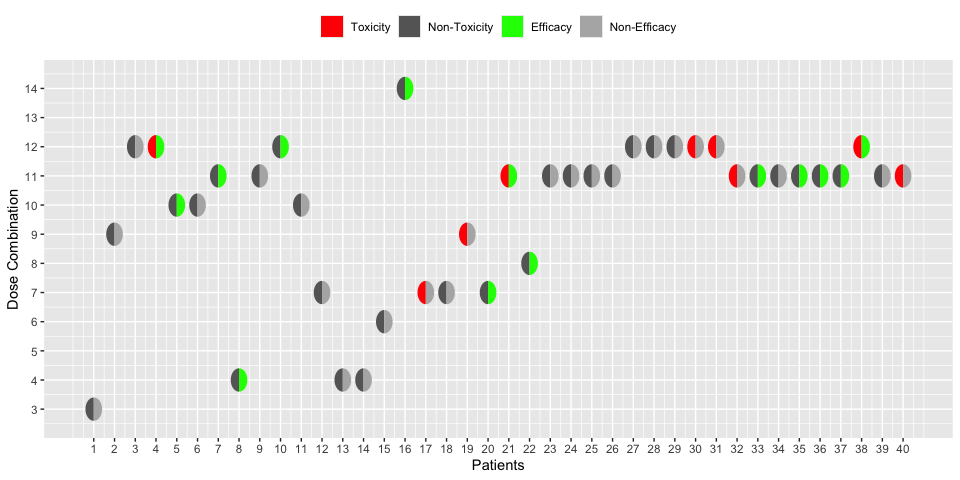

```r
# generate plots of patient enrollment of the first trial
enroll_patient_plot(simRes$datALL[[3]])
```

The second plot is for patient allocations by dose combination of the third simulated trial shown by a histogram.

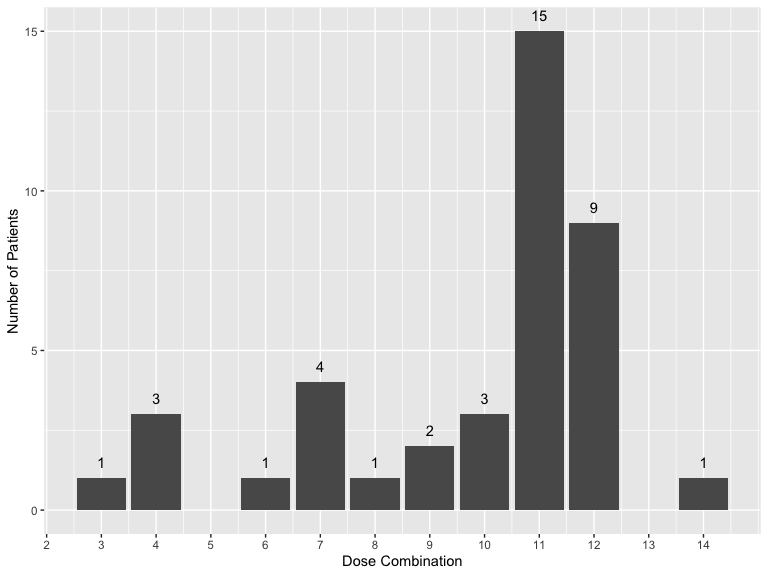

```r
# generate plots of patient allocations by dose levels of the first trial
patient_allocation_plot(simRes$datALL[[3]])
```

In addition, the overall optimal dose combination (ODC) selection can be plotted by a histogram among total of $100$ simulations for this example.

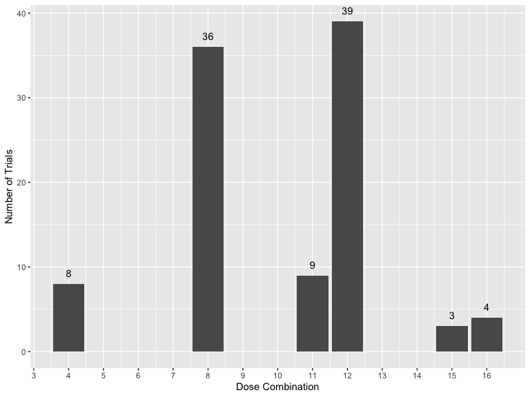

```r
# generate plots of ODC selections among all trials
ODC_plot(simRes)
```

#### Simulation of a single trial patient allocation

Intermediate functions $get\_orderings()$, $toxicity\_est()$, and $efficacy\_est()$ have been created to streamline the whole simulation process that is included in the $SIM\_phase\_I\_II()$ function, as described above. These functions can also be used to perform a single simulation for providing the allocation of the next patient based on the existing data.

An example dataset, representing six patients already enrolled using a 4x4 dose combination matrix, is provided below.

```r
set.seed(123)
currDat <- data.frame(sample(1:6, 6, replace=TRUE), rbinom(6, 1, 0.2), rbinom(6, 1, 0.5))
names(currDat) <- c("DoseLevel", "DLT", "ORR")
currDat
```

```
##   DoseLevel DLT ORR
## 1         3   0   0
## 2         6   0   1
## 3         3   1   0
## 4         2   0   0
## 5         2   0   0
## 6         6   0   1
```

The $get\_ordering()$ function can be implemented to get the possible toxicity and efficacy orderings for dose combinations when there is no prior information available for the combined drugs.

```r
orderings <- get_ordering(doseComb_forMat=c(4,4), type_forMat="matrix")
orderings
```

```
## [[1]]
##  [1]  1  2  3  4  5  6  7  8  9 10 11 12 13 14 15 16
##
## [[2]]
##  [1]  1  5  9 13  2  6 10 14  3  7 11 15  4  8 12 16
##
## [[3]]
##  [1]  1  5  2  9  6  3 13 10  7  4 14 11  8 15 12 16
##
## [[4]]
##  [1]  1  2  5  3  6  9  4  7 10 13  8 11 14 12 15 16
##
## [[5]]
##  [1]  1  5  2  3  6  9 13 10  7  4  8 11 14 15 12 16
##
## [[6]]
##  [1]  1  2  5  9  6  3  4  7 10 13 14 11  8 12 15 16
```

Then, we can obtain the toxicity and efficacy orderings by modifying the orderings of the pre-specified skeletons generated by the $priorSkeletons()$ function.

```r
DLT <- lapply(orderings, function(or){DLT_skeleton[order(or)]})
ORR <- lapply(orderings, function(or){Efficacy_skeleton[order(or)]})
lapply(DLT, function (x) round(x, 3))
```

```
## [[1]]
##  [1] 0.015 0.026 0.042 0.063 0.090 0.123 0.161 0.204 0.251 0.300 0.351 0.402
## [13] 0.452 0.501 0.548 0.592
##
## [[2]]
##  [1] 0.015 0.090 0.251 0.452 0.026 0.123 0.300 0.501 0.042 0.161 0.351 0.548
## [13] 0.063 0.204 0.402 0.592
##
## [[3]]
##  [1] 0.015 0.042 0.123 0.300 0.026 0.090 0.251 0.452 0.063 0.204 0.402 0.548
## [13] 0.161 0.351 0.501 0.592
##
## [[4]]
##  [1] 0.015 0.026 0.063 0.161 0.042 0.090 0.204 0.351 0.123 0.251 0.402 0.501
## [13] 0.300 0.452 0.548 0.592
##
## [[5]]
##  [1] 0.015 0.042 0.063 0.300 0.026 0.090 0.251 0.351 0.123 0.204 0.402 0.548
## [13] 0.161 0.452 0.501 0.592
##
## [[6]]
##  [1] 0.015 0.026 0.123 0.161 0.042 0.090 0.204 0.452 0.063 0.251 0.402 0.501
## [13] 0.300 0.351 0.548 0.592
```

```r
lapply(ORR, function (x) round(x, 3))
```

```
## [[1]]
##  [1] 0.079 0.111 0.149 0.192 0.240 0.291 0.343 0.396 0.449 0.500 0.549 0.595
## [13] 0.638 0.678 0.714 0.747
##
## [[2]]
##  [1] 0.079 0.240 0.449 0.638 0.111 0.291 0.500 0.678 0.149 0.343 0.549 0.714
## [13] 0.192 0.396 0.595 0.747
##
## [[3]]
##  [1] 0.079 0.149 0.291 0.500 0.111 0.240 0.449 0.638 0.192 0.396 0.595 0.714
## [13] 0.343 0.549 0.678 0.747
##
## [[4]]
##  [1] 0.079 0.111 0.192 0.343 0.149 0.240 0.396 0.549 0.291 0.449 0.595 0.678
## [13] 0.500 0.638 0.714 0.747
##
## [[5]]
##  [1] 0.079 0.149 0.192 0.500 0.111 0.240 0.449 0.549 0.291 0.396 0.595 0.714
## [13] 0.343 0.638 0.678 0.747
##
## [[6]]
##  [1] 0.079 0.111 0.291 0.343 0.149 0.240 0.396 0.638 0.192 0.449 0.595 0.678
## [13] 0.500 0.549 0.714 0.747
```

Based on these established toxicity skeleton and orderings, the $toxicity\_est()$ function can be used to estimate toxicity probabilities for each dose combination, given current data. The function returns a list that contains dose combinations within the acceptable set and the posterior density of toxicity orderings, which are instrumental for subsequent toxicity estimations.

```r
tox <- toxicity_est(Dat=currDat, I=16, M=6,
    M_prob=rep(1/6,6), DLT_skeleton=DLT, DLT_thresh=0.3,
    model="empiric", para_prior="normal", beta_mean=0,
    beta_sd=1, intcpt_lgst1=NULL, beta_shape=NULL,
    beta_inverse_scale=NULL, alpha_mean=NULL,
    alpha_sd=NULL, alpha_shape=NULL,
    alpha_inverse_scale=NULL, seed=23)
tox
```

```
## $mStar
## [1] 2
##
## $piT_hat
##  [1] 0.01487417 0.08914613 0.24937723 0.45030566 0.02564017 0.12188768
##  [7] 0.29847219 0.49927951 0.04119148 0.16004316 0.34902104 0.54623338
## [13] 0.06223750 0.20286601 0.39995108 0.59069275
##
## $AR
##  [1]  1  2  3  5  6  7  9 10 13 14
##
## $M_prob
## [1] 0.09171863 0.25757586 0.19113489 0.13280305 0.12322751 0.20354007
```

Following the determination of the acceptable set of dose combinations from the toxicity estimation (as indicated by the results below $\$AR$, the $efficacy\_est()$ function can be used to estimate efficacy probabilities. This allows us to identify the most suitable dose combination for allocating the next patient or patient cohort.

```r
eff <- efficacy_est(Dat=currDat, AR=tox$AR, I=16, K=6,
    K_prob=rep(1/6,6), efficacy_skeleton=ORR, Nphas=20,
    model="empiric", para_prior="normal", theta_mean=0,
    theta_sd=1, theta_intcpt_lgst1=NULL, theta_shape=NULL,
    theta_inverse_scale=NULL, alphaT_mean=NULL,
    alphaT_sd=NULL, alphaT_shape=NULL,
    alphaT_inverse_scale=NULL, seed=23, seed_rand=23,
    seed_max=23)
eff
```

```
## $kStar
## [1] 1
##
## $piE_hat
##  [1] 0.1567171 0.2010601 0.2494524 0.3006473 0.3533686 0.4064103 0.4587076
##  [8] 0.5093772 0.5577318 0.6032763 0.6456898 0.6848013 0.7205622 0.7530196
## [15] 0.7822914 0.8085451
##
## $piE_hat_AR
##  [1] 0.1567171 0.2010601 0.2494524 0.3533686 0.4064103 0.4587076 0.5577318
##  [8] 0.6032763 0.7205622 0.7530196
##
## $di
## [1] 9
##
## $K_prob
## [1] 0.29945301 0.07716737 0.12316523 0.19191199 0.16922609 0.13907631
```

The next patient or cohort of patients will be allocated to dose combination $\texttt{#}9$ and posterior density of efficacy orderings will be used for next efficacy estimations.

#### Simulations of list of input values

If there are lists of input values for several parameters, we can use the for loop with the $SIM\_phase\_I\_II()$ function to obtain multiple sets of results.

We provided the examples of the six scenarios given by Wages and Conaway (2014). We included several different commonly considered values of the parameters including (1) maximum sample size $N = c(40, 50, 60)$, (2) pre-specified toxicity and efficacy skeletons $Skeleton = c(1,2)$, (3) number of patients for determination of randomization phase $nR=c(10, 20, 30)$, and (4) Association parameter for efficacy and toxicity $corr=c(0, -2.049, 0.814)$ were based on simulation results given by Thall and Cook (2004). The results are saved as “examples_results.RData” in the crm12Comb package. The result data can directly be used to obtain plots comparing among four different link functions using $sample\_plot()$ function.

Here are the six scenarios.

|  |  |  | True (toxicity, efficacy) probabilities |  |
| --- | --- | --- | --- | --- |
|  | Doses of |  | Doses of B |  |
| Scenario | A | 1 | 2 | 3 |
| 1 | 3 | (0.08, 0.15) | (0.10, 0.20) | **(0.18, 0.40)** |
|  | 2 | (0.04, 0.10) | (0.06, 0.16) | (0.08, 0.20) |
|  | 1 | (0.02, 0.05) | (0.04, 0.10) | (0.06, 0.15) |
| 2 | 3 | (0.16, 0.20) | **(0.25, 0.35)** | (0.35, 0.50) |
|  | 2 | (0.10, 0.10) | (0.14, 0.25) | **(0.20, 0.40)** |
|  | 1 | (0.06, 0.05) | (0.08, 0.10) | (0.12, 0.20) |
| 3 | 3 | **(0.24, 0.40)** | (0.33, 0.50) | (0.40, 0.60) |
|  | 2 | (0.16, 0.20) | **(0.22, 0.40)** | (0.35, 0.50) |
|  | 1 | (0.08, 0.10) | (0.14, 0.25) | **(0.20, 0.35)** |
| 4 | 3 | (0.33, 0.50) | (0.40, 0.60) | (0.55, 0.70) |
|  | 2 | **(0.18, 0.35)** | **(0.25, 0.45)** | (0.42, 0.55) |
|  | 1 | (0.12, 0.20) | **(0.20, 0.40)** | (0.35, 0.50) |
| 5 | 3 | (0.45, 0.55) | (0.55, 0.65) | (0.75, 0.75) |
|  | 2 | **(0.20, 0.36)** | (0.35, 0.49) | (0.40, 0.62) |
|  | 1 | (0.15, 0.20) | **(0.20, 0.35)** | **(0.25, 0.50)** |
| 6 | 3 | (0.65, 0.60) | (0.80, 0.65) | (0.85, 0.70) |
|  | 2 | (0.55, 0.55) | (0.70, 0.60) | (0.75, 0.65) |
|  | 1 | (0.50, 0.50) | (0.55, 0.55) | (0.65, 0.60) |

The code below shows how to input the true probabilities in the form of matrix with scenario 1 as an example.

```r
scenario1 <- matrix(c(0.02, 0.05,
                      0.04, 0.10,
                      0.06, 0.15,
                      0.04, 0.10,
                      0.06, 0.16,
                      0.08, 0.20,
                      0.08, 0.15,
                      0.10, 0.20,
                      0.18, 0.40), ncol=2, byrow = TRUE)
```

The example code shows an approach to obtain the results with list of input values. Based on the scenarios, we first construct the total of $54$ in consist of conditions $2$ pre-specified toxicity and efficacy skeletons, $3$ maximum sample sizes, $3$ numbers of patients for determination of randomization phase and $3$ association parameters for efficacy and toxicity.

```r
orderings <- function(DLT1, DLT2, ORR1, ORR2){
  input_Nphase <- c(10, 20, 30)
  input_corr <- c(0, -2.049, 0.814)
  input_N <- c(40, 50, 60)
  DLTs <- list(DLT1, DLT2)
  ORRs <- list(ORR1, ORR2)

  conds <- list()
  i <- 1
  conds <- list()
  i <- 1
  for (s in 1:2){
    for (n in 1:3){
      for (np in 1:3){
        for (c in 1:3){
          conds[[i]] <- list(DLT=DLTs[[s]], ORR=ORRs[[s]], sklnum = s,
                             N=input_N[n], Nphase=input_Nphase[np],
                             corr=input_corr[c])
          i <- i+1
        }
      }
    }
  }

  return(conds)
}

SC <- list(scenario1, scenario2, scenario3, scenario4, scenario5, scenario6)
```

The second step is to build the output data set with detailed names of 9 operating characteristics.

```r
output <- data.frame(Scenario = double(), Skeleton = double(),
  N = double(), nR = double(), corr = double(), safe = double(),
  target = double(), toxic = double(), avgSS = double(),
  prop_ODC = double(), stop_safety = double(), stop_futility = double(),
  o_DLT = double(), o_ORR = double())

colnames(output) <- c("Scenario", "Skeleton", "N", "nR", "corr",
  "Probability of recommending safe/ineffective combinations as ODC",
  "Probability of recommending target combinations as ODC",
  "Probability of recommending overly toxic combinations as ODC",
  "Mean # of patients enrolled", "Proportion of patients allocated to true ODC(s)",
  "Proportion stopped for safety", "Proportion stopped for futility",
  "Observed DLT rate", "Observed response rate")
```

The third step is to specify two sets of toxicity and efficacy skeletons so that we can plug the skeletons into the $orderings()$ function to stored $54$ conditions into a list named $conds$.

```r
# empiric, normal prior
DLT_skeleton1 <- priorSkeletons(updelta=0.045, target=0.3, npos=5, ndose=9,
                                model = "empiric", prior = "normal", beta_mean=0)
DLT_skeleton2 <- priorSkeletons(updelta=0.06, target=0.3, npos=4, ndose=9,
                                model = "empiric", prior = "normal", beta_mean=0)
Efficacy_skeleton1 <- priorSkeletons(updelta=0.045, target=0.5, npos=5, ndose=9,
                                     model = "empiric", prior = "normal", beta_mean=0)
Efficacy_skeleton2 <- priorSkeletons(updelta=0.06, target=0.5, npos=4, ndose=9,
                                     model = "empiric", prior = "normal", beta_mean=0)

conds <- orderings(DLT1=DLT_skeleton1, DLT2=DLT_skeleton2,
                  ORR1=Efficacy_skeleton1, ORR2=Efficacy_skeleton2)
```

The last step is to iterate over the $6$ scenarios and $54$ conditions each with $1000$ simulations, storing the results into the output data set after each iteration.

```r
for (s in 1:length(SC)){
  for (c in 1:length(conds)){
    print(paste0("Scenario=", s, ", skeleton=", conds[[c]]$sklnum,
                 ", N=", conds[[c]]$N, ", nR=", conds[[c]]$Nphase,
                 ", corr=", conds[[c]]$corr))
    curr = SIM_phase_I_II(nsim=1000, Nmax=conds[[c]]$N, DoseComb=SC[[s]],
                          input_doseComb_forMat=c(3,3),
                          input_type_forMat="matrix",
                          input_Nphase=conds[[c]]$Nphase,
                          input_DLT_skeleton=conds[[c]]$DLT,
                          input_efficacy_skeleton=conds[[c]]$ORR,
                          input_DLT_thresh=0.3, input_efficacy_thresh=0.3,
                          input_cohortsize=1, input_corr=conds[[c]]$corr,
                          input_early_stopping_safety_thresh=0.33,
                          input_early_stopping_futility_thresh=0.2,
                          input_model="empiric", input_para_prior="normal",
                          input_beta_mean=0, input_beta_sd=sqrt(1.34),
                          input_theta_mean=0, input_theta_sd=sqrt(1.34),
                          random_seed=42)
    currTmp = data.frame(s, conds[[c]]$sklnum, conds[[c]]$N, conds[[c]]$Nphase, conds[[c]]$corr,
                         curr$prob_safe, curr$prob_target, curr$prob_toxic, curr$mean_SS, curr$mean_ODC,
                         curr$prob_stop_safety, curr$prob_stop_futility, curr$mean_DLT, curr$mean_ORR)
    output = rbind(output, currTmp)
  }
}
```

The process above is an example of using one link function “empiric” with normal prior. We also ran other link functions including “tanh” with exponential prior, “one-parameter logistic” with normal and gamma priors. We stored the corresponding results into a data set located at $inst/extdata/example\_results.RData$ in the $crm12Comb$ package.

```r
data(examples_results, package = "crm12Comb")
```

Here are two examples of plotting the result data by fixing three parameters and drawing the relationship between the specific operating characteristic and the non-fixed parameter. The first example showing the relationship between “Probability of ODC as target combinations” versus (3) “number of patients for determination of randomization phase” after fixing (1), (2) and (4).

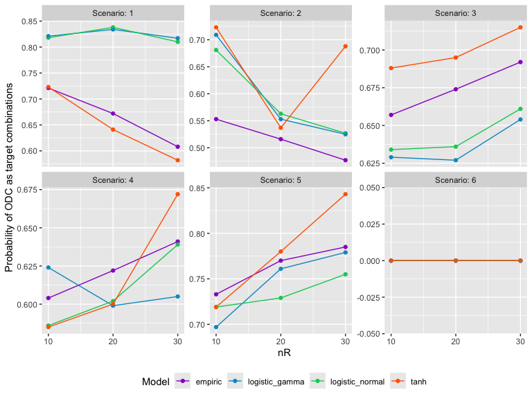

```r
sample_plot(examples_results, outcome = "prob_target",
            outname = "Probability of ODC as target combinations",
            N = 40, nR = NULL, Skeleton = 1, corr = 0)
```

The second example showing the relationship between “Proportion of patients allocated to true ODC(s)” versus (4) “Association parameter for efficacy and toxicity” after fixing (1), (2) and (3).

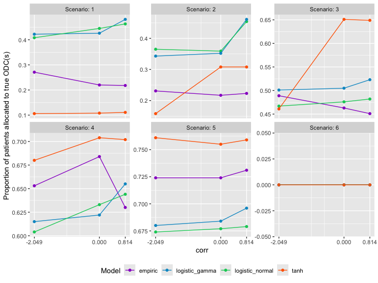

```r
sample_plot(examples_results, outcome = "mean_ODC",
            outname = "Proportion of patients allocated to true ODC(s)",
            N = 60, nR = 30, Skeleton = 2, corr = NULL)
```

### References

Murtaugh, P. A., & Fisher, L. D. (1990). Bivariate binary models of efficacy and toxicity in dose-ranging trials. Communications in Statistics-Theory and Methods, 19(6), 2003-2020. https://doi.org/10.1080/03610929008830305

O’Quigley, J., Pepe, M., & Fisher, L. (1990). Continual reassessment method: a practical design for phase 1 clinical trials in cancer. Biometrics, 33-48. https://doi.org/10.2307/2531628

Thall, P. F., & Cook, J. D. (2004). Dose‐finding based on efficacy–toxicity trade‐offs. Biometrics, 60(3), 684-693. https://doi.org/10.1111/j.0006-341X.2004.00218.x

Lee, S. M., & Cheung, Y. K. (2009). Model calibration in the continual reassessment method. Clinical Trials, 6(3), 227-238. https://doi.org/10.1177/1740774509105076

Wages, N. A., & Conaway, M. R. (2013). Specifications of a continual reassessment method design for phase I trials of combined drugs. Pharmaceutical statistics, 12(4), 217-224. https://doi.org/10.1002/pst.1575

Wages, N. A., & Conaway, M. R. (2014). Phase I/II adaptive design for drug combination oncology trials. Statistics in medicine, 33(12), 1990-2003. https://doi.org/10.1002/sim.6097